# Bellabeat Case Study

Derick A. Pullen

2025-09-16

## Ask

**Business Task**  
Analyze smart device usage data to gain insight into how consumers use non-Bellabeat smart devices.  
Use these insights to make high-level recommendations for how Bellabeat can apply them to one of its products and improve marketing strategy.

**Key Stakeholders**  
- **Urška Sršen** – Bellabeat’s cofounder and Chief Creative Officer  
- **Sando Mur** – Bellabeat’s cofounder and key member of the executive team  
- **Bellabeat Marketing Analytics Team** – responsible for analyzing data and guiding marketing strategy  
- **Bellabeat Customers** – the end users who benefit from improved product features and health insights

## Prepare

**Organization**  
- Each dataset is stored in **CSV format**.  
- Data is in a **wide format** (one row per user per date).  
- Common keys: `Id` (user) and `Date` (day of activity/sleep/weight).

**Licensing and Accessibility**  
- The dataset is CC0: Public Domain, meaning it is free to use without restrictions.  
- No privacy concerns since user identities are anonymized.

**Data Integrity**  
- Verified that files opened correctly and contained expected columns.  
- Initial inspection showed duplicates in `sleep_day_raw.csv` that required cleaning.

## Process

### Load Packages

```r
library(tidyverse)   # readr, dplyr, ggplot2, etc.
library(janitor)     # clean_names()
```

### Read RAW Files

```r
daily_raw  <- readr::read_csv("data/raw/case_study_2_bellabeat_daily_activity_R.csv")
sleep_raw  <- readr::read_csv("data/raw/case_study_2_bellabeat_sleep_data_R.csv")
weight_raw <- readr::read_csv("data/raw/case_study_2_bellabeat_weight_data_R.csv")
```

### Clean column names, remove duplicates, fix dates

```r
# Daily
daily <- daily_raw %>%
  clean_names() %>%
  distinct() %>%
  mutate(activity_date = as.Date(activity_date, tryFormats = c("%m/%d/%Y","%Y-%m-%d")))

# Sleep
sleep <- sleep_raw %>%
  clean_names() %>%
  distinct() %>%
  mutate(sleep_day = as.Date(sleep_day, tryFormats = c("%m/%d/%Y","%Y-%m-%d")))

# Weight
weight <- weight_raw %>%
  clean_names() %>%
  distinct() %>%
  mutate(
    date = as.Date(date, tryFormats = c("%m/%d/%Y","%Y-%m-%d"))
  )
```

```r
# assumes daily and sleep were already read/cleaned in earlier chunks
daily_sleep <- daily %>%
  inner_join(sleep, by = c("id" = "id",
                           "activity_date" = "sleep_day"))

# optional feature engineering
daily_sleep <- daily_sleep %>%
  mutate(
    sleep_hours = total_minutes_asleep / 60,
    in_bed_hours = total_time_in_bed / 60,
    sleep_efficiency = if_else(in_bed_hours > 0, sleep_hours / in_bed_hours, NA_real_)
  )
```

## Analyze

The cleaned datasets were organized by user ID and date. Daily activity and sleep logs were merged to allow cross-analysis (steps vs. sleep). Weight logs remain separate due to limited participation

### Daily Activity Levels

```r
# % of days with 10k+ steps
pct_days_10k <- mean(daily$total_steps >= 10000, na.rm = TRUE) * 100
round(pct_days_10k, 1)
```

```
## [1] 32.2
```

**Insight:**  
Only about 32.2% of all logged days reached the 10,000-step benchmark.  
This indicates most users are not consistently meeting the recommended daily activity levels.

All datasets were properly formatted for analysis. Dates were stored in Date format, numeric fields in numeric format, and duplicates removed.

```r
glimpse(daily)
```

```
## Rows: 940
## Columns: 15
## $ id                         <dbl> 1503960366, 1503960366, 1503960366, 1503960…
## $ activity_date              <date> 2016-04-12, 2016-04-13, 2016-04-14, 2016-0…
## $ total_steps                <dbl> 13162, 10735, 10460, 9762, 12669, 9705, 130…
## $ total_distance             <dbl> 8.50, 6.97, 6.74, 6.28, 8.16, 6.48, 8.59, 9…
## $ tracker_distance           <dbl> 8.50, 6.97, 6.74, 6.28, 8.16, 6.48, 8.59, 9…
## $ logged_activities_distance <dbl> 0, 0, 0, 0, 0, 0, 0, 0, 0, 0, 0, 0, 0, 0, 0…
## $ very_active_distance       <dbl> 1.88, 1.57, 2.44, 2.14, 2.71, 3.19, 3.25, 3…
## $ moderately_active_distance <dbl> 0.55, 0.69, 0.40, 1.26, 0.41, 0.78, 0.64, 1…
## $ light_active_distance      <dbl> 6.06, 4.71, 3.91, 2.83, 5.04, 2.51, 4.71, 5…
## $ sedentary_active_distance  <dbl> 0, 0, 0, 0, 0, 0, 0, 0, 0, 0, 0, 0, 0, 0, 0…
## $ very_active_minutes        <dbl> 25, 21, 30, 29, 36, 38, 42, 50, 28, 19, 66,…
## $ fairly_active_minutes      <dbl> 13, 19, 11, 34, 10, 20, 16, 31, 12, 8, 27, …
## $ lightly_active_minutes     <dbl> 328, 217, 181, 209, 221, 164, 233, 264, 205…
## $ sedentary_minutes          <dbl> 728, 776, 1218, 726, 773, 539, 1149, 775, 8…
## $ calories                   <dbl> 1985, 1797, 1776, 1745, 1863, 1728, 1921, 2…
```

```r
glimpse(sleep)
```

```
## Rows: 410
## Columns: 5
## $ id                   <dbl> 1503960366, 1503960366, 1503960366, 1503960366, 1…
## $ sleep_day            <date> 2016-04-12, 2016-04-13, 2016-04-15, 2016-04-16, …
## $ total_sleep_records  <dbl> 1, 2, 1, 2, 1, 1, 1, 1, 1, 1, 1, 1, 1, 1, 1, 1, 1…
## $ total_minutes_asleep <dbl> 327, 384, 412, 340, 700, 304, 360, 325, 361, 430,…
## $ total_time_in_bed    <dbl> 346, 407, 442, 367, 712, 320, 377, 364, 384, 449,…
```

```r
user_avg <- daily %>%
  group_by(id) %>%
  summarise(avg_steps = mean(total_steps, na.rm = TRUE))

summary(user_avg$avg_steps)
```

```
##    Min. 1st Qu.  Median    Mean 3rd Qu.    Max.
##   916.1  5566.9  7283.0  7519.3  9519.7 16040.0
```

```r
mean(user_avg$avg_steps >= 10000) * 100
```

```
## [1] 21.21212
```

Surprisingly, only a small percentage of users averaged 10,000 steps per day across the dataset, suggesting most are falling short of CDC’s activity recommendation.

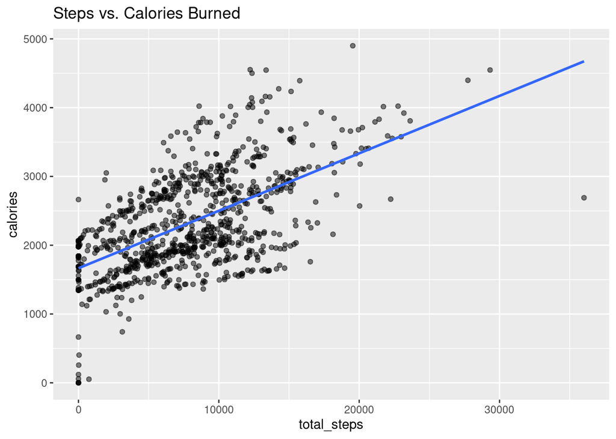

```r
ggplot(daily, aes(total_steps, calories)) +
  geom_point(alpha = 0.5) +
  geom_smooth(method = "lm", se = FALSE) +
  labs(title="Steps vs. Calories Burned")
```

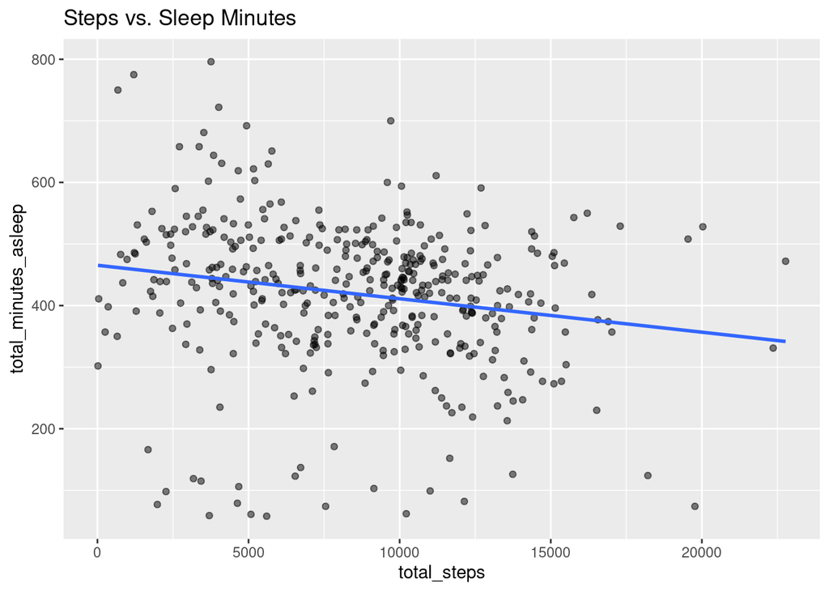

```r
ggplot(daily_sleep, aes(total_steps, total_minutes_asleep)) +
  geom_point(alpha=0.5) +
  geom_smooth(method="lm", se=FALSE) +
  labs(title="Steps vs. Sleep Minutes")
```

## Sleep Analysis

### Build / Load merged daily + sleep (safe guard)

```r
library(readr); library(dplyr)

# If the object isn't in memory, try to read the saved merged file
if (!exists("daily_sleep")) {
  if (file.exists("data/cleaned/daily_sleep_merged.csv")) {
    daily_sleep <- readr::read_csv("data/cleaned/daily_sleep_merged.csv")
  } else {
    # If you didn't save it earlier, build it now from daily + sleep
    daily_sleep <- daily %>%
      inner_join(sleep, by = c("id" = "id", "activity_date" = "sleep_day"))
  }
}

# Ensure helper columns exist
daily_sleep <- daily_sleep %>%
  mutate(
    sleep_hours   = total_minutes_asleep / 60,
    in_bed_hours  = total_time_in_bed   / 60,
    sleep_efficiency = dplyr::if_else(in_bed_hours > 0, sleep_hours / in_bed_hours, NA_real_)
  )
```

### Key sleep metrics (daily level)

```r
# % of days with at least 7 hours slept
pct_days_7h <- mean(daily_sleep$sleep_hours >= 7, na.rm = TRUE) * 100

# Central tendency (daily)
sleep_mean  <- mean(daily_sleep$sleep_hours, na.rm = TRUE)
sleep_median<- median(daily_sleep$sleep_hours, na.rm = TRUE)

# Sleep efficiency (as %)
eff_mean <- mean(daily_sleep$sleep_efficiency, na.rm = TRUE) * 100
```

**Insight (daily level):**  
On a typical logged day, users slept about **7 hours** (median **7.2**), and only **55.9%** of days met the **7+ hours** guideline.  
Average **sleep efficiency** (time asleep ÷ time in bed) was **92%**, indicating some in-bed time isn’t translating to sleep.

### User-level sleep (consistency by person)

```r
sleep_user <- daily_sleep %>%
  group_by(id) %>%
  summarise(
    days_logged = n(),
    avg_sleep_hours = mean(sleep_hours, na.rm = TRUE),
    avg_efficiency  = mean(sleep_efficiency, na.rm = TRUE),
    .groups = "drop"
  )

# % of users who average at least 7 hours/night
pct_users_avg_7h <- mean(sleep_user$avg_sleep_hours >= 7, na.rm = TRUE) * 100
```

**Insight (user level):**  
Only **45.8%** of users **average** at least 7 hours of sleep. This suggests **chronic short sleep** for many users, not just occasional short nights.

### Visuals: distribution & efficiency

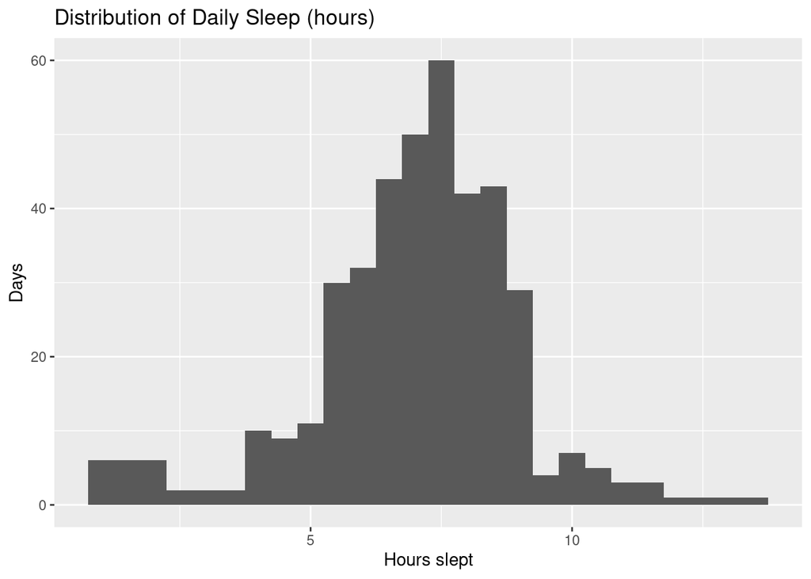

```r
library(ggplot2)

ggplot(daily_sleep, aes(x = sleep_hours)) +
  geom_histogram(binwidth = 0.5) +
  labs(title = "Distribution of Daily Sleep (hours)",
       x = "Hours slept",
       y = "Days")
```

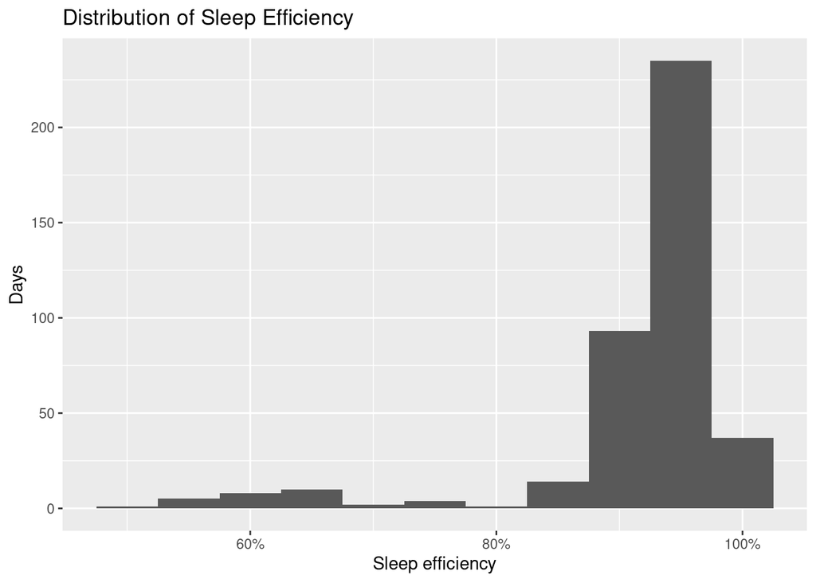

```r
ggplot(daily_sleep, aes(x = sleep_efficiency)) +
  geom_histogram(binwidth = 0.05) +
  scale_x_continuous(labels = scales::percent_format(accuracy = 1)) +
  labs(title = "Distribution of Sleep Efficiency",
       x = "Sleep efficiency",
       y = "Days")
```

### Relationship: steps vs. sleep

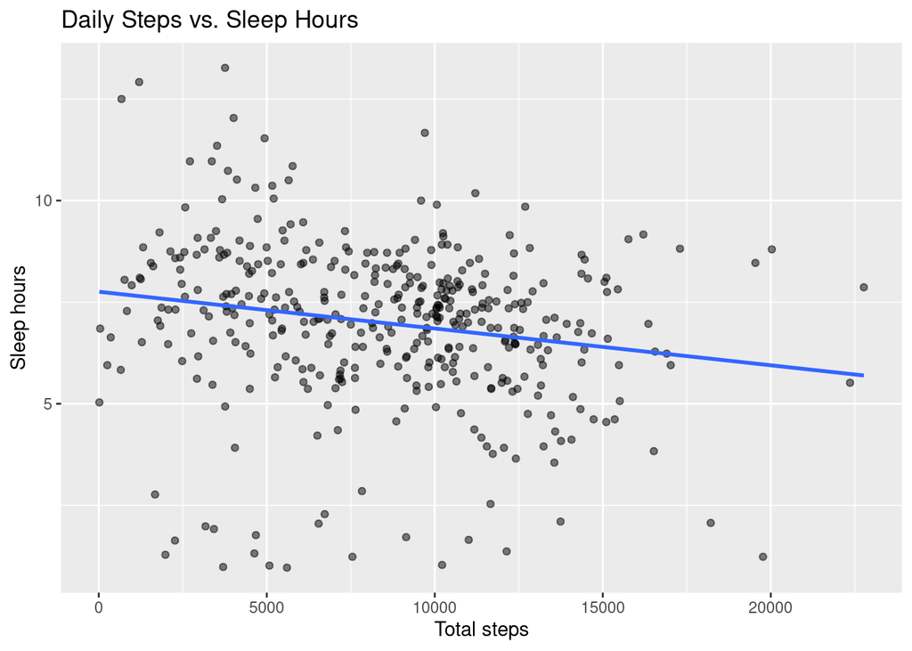

```r
ggplot(daily_sleep, aes(x = total_steps, y = sleep_hours)) +
  geom_point(alpha = 0.5) +
  geom_smooth(method = "lm", se = FALSE) +
  labs(title = "Daily Steps vs. Sleep Hours",
       x = "Total steps",
       y = "Sleep hours")
```

```r
# Correlation (will be small in many Fitbit samples)
steps_sleep_cor <- suppressWarnings(cor(daily_sleep$total_steps, daily_sleep$sleep_hours, use = "complete.obs"))
round(steps_sleep_cor, 2)
```

```
## [1] -0.19
```

**Insight (relationship):**  
The correlation between steps and sleep is **-0.19** (where 0 = no linear relationship). This suggests that **higher activity does not strongly predict longer sleep** in this sample—meaning sleep support features should be addressed **independently** of activity coaching.

### Business “So what?”

- Many users **don’t reach 7 hours** consistently → opportunity for **sleep reminders**, **wind-down routines**, and **bedtime coaching** in the app.
- **Efficiency gaps** (awake time in bed) → position **smart bedtime nudges**, **breathing/stress features**, and **sleep hygiene tips**.
- Weak steps↔︎sleep link → market sleep support as a **standalone value** (not just a byproduct of activity).

## Weight Participation

### How many users logged weight? What’s the average BMI?

```r
library(dplyr)

# Total unique users in the study (use daily as the universe)
n_users_total <- dplyr::n_distinct(daily$id)

# Users who logged any weight entry
n_users_weight <- dplyr::n_distinct(weight$id)

# Participation rate (% of users who ever logged weight)
weight_participation_pct <- (n_users_weight / n_users_total) * 100

# Overall BMI summary among available weight entries
avg_bmi   <- mean(weight$bmi, na.rm = TRUE)
med_bmi   <- median(weight$bmi, na.rm = TRUE)
n_bmi_obs <- sum(!is.na(weight$bmi))

# (Optional) Manual vs smart scale breakdown if column exists
has_manual <- "is_manual_report" %in% names(weight)
if (has_manual) {
  manual_share <- mean(weight$is_manual_report == TRUE, na.rm = TRUE) * 100
} else {
  manual_share <- NA_real_
}

list(
  total_users               = n_users_total,
  users_with_weight_entries = n_users_weight,
  participation_percent     = round(weight_participation_pct, 1),
  avg_bmi                   = round(avg_bmi, 1),
  median_bmi                = round(med_bmi, 1),
  bmi_observations          = n_bmi_obs,
  manual_entry_percent      = ifelse(is.na(manual_share), "N/A", paste0(round(manual_share,1), "%"))
)
```

```
## $total_users
## [1] 33
##
## $users_with_weight_entries
## [1] 8
##
## $participation_percent
## [1] 24.2
##
## $avg_bmi
## [1] 25.2
##
## $median_bmi
## [1] 24.4
##
## $bmi_observations
## [1] 67
##
## $manual_entry_percent
## [1] "61.2%"
```

**Insight (participation):**  
Out of **33** users, **8** logged weight at least once (**24.2%** participation).  
Weight logging is relatively **sparse**, suggesting users are less consistent with **manual** metrics than automatic ones (steps/sleep).

**Insight (BMI):**  
Among available entries (**67** records), average BMI is **25.2** (median **24.4**).  
This provides context for Bellabeat to **personalize guidance** (e.g., goals, tips) based on users’ body metrics.

### BMI distribution

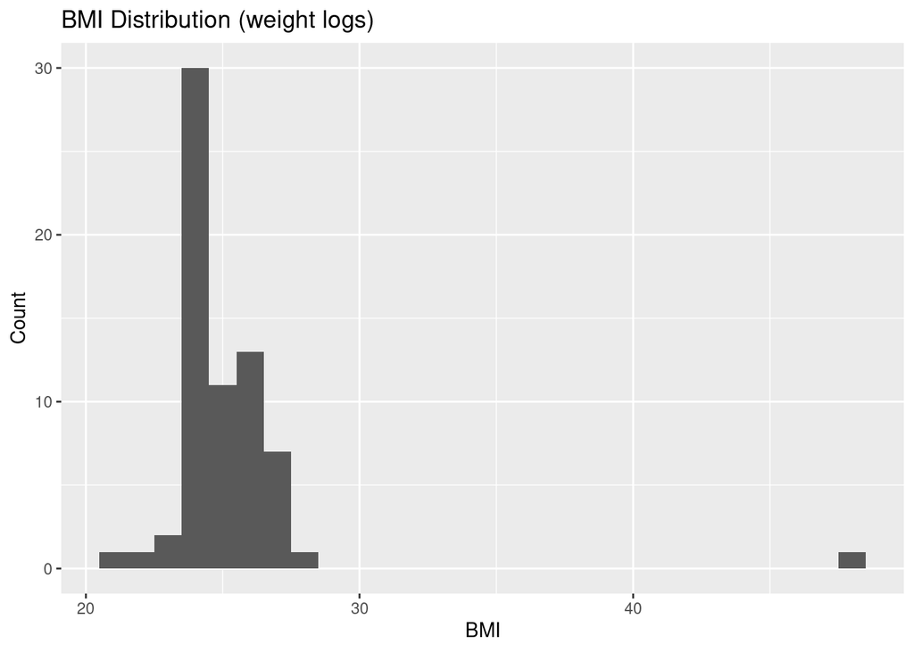

```r
library(ggplot2)

ggplot(weight, aes(x = bmi)) +
  geom_histogram(binwidth = 1) +
  labs(title = "BMI Distribution (weight logs)",
       x = "BMI",
       y = "Count")
```

### Manual vs. Smart scale logging

```
## # A tibble: 2 × 2
##   type           n
##   <chr>      <int>
## 1 Manual        41
## 2 Smart/Auto    26
```

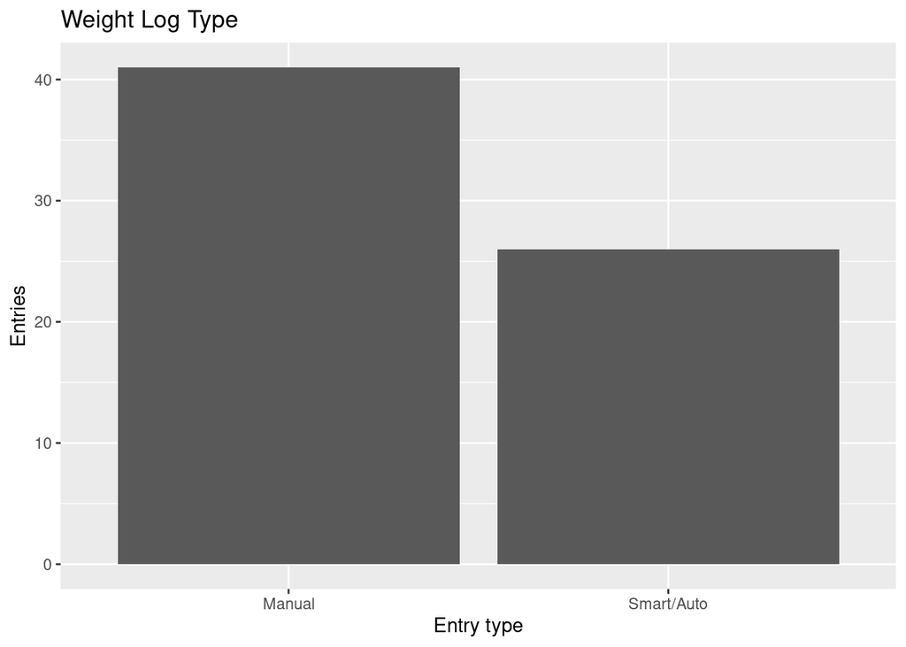

```r
if ("is_manual_report" %in% names(weight)) {
  weight_log_type <- weight %>%
    mutate(type = ifelse(is_manual_report, "Manual", "Smart/Auto")) %>%
    count(type)

  print(weight_log_type)

  # Simple bar (optional)
  ggplot(weight_log_type, aes(type, n)) +
    geom_col() +
    labs(title = "Weight Log Type",
         x = "Entry type",
         y = "Entries")
} else {
  "Log type column (is_manual_report) not present in this dataset."
}
```

### Business “So what?”

- **Low participation** in weight logging suggests Bellabeat should **minimize manual entry friction** and emphasize **automatic capture** where possible (e.g., smart scale syncs, reminders).
- Use BMI (when available) to **personalize** educational content and **goal setting**, but avoid relying on it for daily engagement—focus primary engagement on **automatic signals** (steps/sleep).

## Summary of Key Metrics

```r
library(dplyr)
library(tibble)

# --- Steps ---
pct_days_10k  <- mean(daily$total_steps >= 10000, na.rm = TRUE) * 100
user_avg      <- daily %>%
  group_by(id) %>%
  summarise(avg_steps = mean(total_steps, na.rm = TRUE), .groups="drop")
pct_users_10k <- mean(user_avg$avg_steps >= 10000, na.rm = TRUE) * 100

# --- Sleep ---
sleep_mean     <- mean(daily_sleep$total_minutes_asleep/60, na.rm = TRUE)
pct_days_7h    <- mean((daily_sleep$total_minutes_asleep/60) >= 7, na.rm = TRUE) * 100
sleep_eff_mean <- mean(daily_sleep$sleep_efficiency, na.rm = TRUE) * 100

# --- Weight ---
n_users_total  <- n_distinct(daily$id)
n_users_weight <- n_distinct(weight$id)
weight_participation_pct <- (n_users_weight / n_users_total) * 100
avg_bmi <- mean(weight$bmi, na.rm = TRUE)

# --- Assemble table ---
summary_tbl <- tibble::tibble(
  Metric = c(
    "% of days with ≥10k steps",
    "% of users averaging ≥10k steps/day",
    "Average sleep hours (per day)",
    "% of days with ≥7h sleep",
    "Avg sleep efficiency (%)",
    "% of users logging weight",
    "Average BMI"
  ),
  Value = c(
    paste0(round(pct_days_10k,1), "%"),
    paste0(round(pct_users_10k,1), "%"),
    round(sleep_mean,1),
    paste0(round(pct_days_7h,1), "%"),
    paste0(round(sleep_eff_mean,0), "%"),
    paste0(round(weight_participation_pct,1), "%"),
    round(avg_bmi,1)
  )
)

knitr::kable(summary_tbl, caption = "Top Metrics Summary")
```

Top Metrics Summary

| Metric | Value |
| --- | --- |
| % of days with ≥10k steps | 32.2% |
| % of users averaging ≥10k steps/day | 21.2% |
| Average sleep hours (per day) | 7 |
| % of days with ≥7h sleep | 55.9% |
| Avg sleep efficiency (%) | 92% |
| % of users logging weight | 24.2% |
| Average BMI | 25.2 |

The summary shows that most users are not consistently meeting recommended activity (≥10k steps) or sleep (≥7h/night) levels. Weight logging participation is very low. These insights suggest Bellabeat can strengthen its competitive position by emphasizing daily movement nudges, sleep support features, and frictionless weight tracking.

## Supporting Visualizations and Key Findings

## Share

```r
library(dplyr); library(ggplot2); library(readr); library(scales)
library(tibble); library(knitr)

# If needed, load cleaned files
if (!exists("daily")  && file.exists("data/cleaned/daily_activity_clean.csv"))  daily  <- read_csv("data/cleaned/daily_activity_clean.csv")
if (!exists("sleep")  && file.exists("data/cleaned/sleep_day_clean.csv"))       sleep  <- read_csv("data/cleaned/sleep_day_clean.csv")
if (!exists("weight") && file.exists("data/cleaned/weight_log_clean.csv"))      weight <- read_csv("data/cleaned/weight_log_clean.csv")

# Ensure merged daily_sleep exists
if (!exists("daily_sleep")) {
  if (file.exists("data/cleaned/daily_sleep_merged.csv")) {
    daily_sleep <- read_csv("data/cleaned/daily_sleep_merged.csv")
  } else {
    daily_sleep <- daily %>% inner_join(sleep, by = c("id"="id","activity_date"="sleep_day"))
  }
}

# Feature engineering (sleep)
if (!"sleep_hours" %in% names(daily_sleep)) {
  daily_sleep <- daily_sleep %>%
    mutate(
      sleep_hours = total_minutes_asleep/60,
      in_bed_hours = total_time_in_bed/60,
      sleep_efficiency = if_else(in_bed_hours>0, sleep_hours/in_bed_hours, NA_real_)
    )
}

# ---- Metrics used in visuals/text ----
pct_days_10k <- mean(daily$total_steps >= 10000, na.rm = TRUE) * 100

user_avg <- daily %>%
  group_by(id) %>%
  summarise(avg_steps = mean(total_steps, na.rm = TRUE), .groups="drop")
pct_users_10k <- mean(user_avg$avg_steps >= 10000, na.rm = TRUE) * 100

sleep_mean <- mean(daily_sleep$sleep_hours, na.rm = TRUE)
pct_days_7h <- mean(daily_sleep$sleep_hours >= 7, na.rm = TRUE) * 100
eff_mean   <- mean(daily_sleep$sleep_efficiency, na.rm = TRUE) * 100

n_users_total  <- dplyr::n_distinct(daily$id)
n_users_weight <- if (exists("weight")) dplyr::n_distinct(weight$id) else NA_integer_
weight_participation_pct <- if (!is.na(n_users_weight)) (n_users_weight/n_users_total)*100 else NA_real_
avg_bmi <- if (exists("weight")) mean(weight$bmi, na.rm = TRUE) else NA_real_

steps_sleep_cor <- suppressWarnings(cor(daily_sleep$total_steps, daily_sleep$sleep_hours, use="complete.obs"))

# Summary table object (used later)
summary_tbl <- tibble(
  Metric = c("% of days with ≥10k steps",
             "% of users averaging ≥10k steps/day",
             "Average sleep hours (per day)",
             "% of days with ≥7h sleep",
             "Avg sleep efficiency (%)",
             "% of users logging weight",
             "Average BMI"),
  Value = c(paste0(round(pct_days_10k,1), "%"),
            paste0(round(pct_users_10k,1), "%"),
            round(sleep_mean,1),
            paste0(round(pct_days_7h,1), "%"),
            paste0(round(eff_mean,0), "%"),
            if (!is.na(weight_participation_pct)) paste0(round(weight_participation_pct,1), "%") else "N/A",
            if (!is.na(avg_bmi)) round(avg_bmi,1) else NA)
)
```

### Daily Steps Distribution

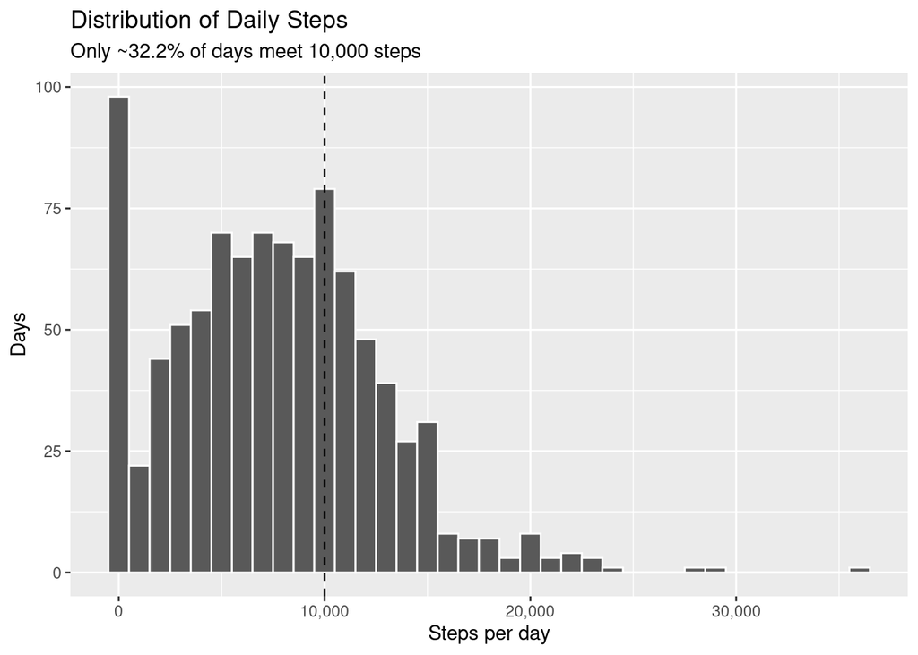

```r
ggplot(daily, aes(x = total_steps)) +
  geom_histogram(binwidth = 1000, color = "white") +
  geom_vline(xintercept = 10000, linetype = "dashed") +
  scale_x_continuous(labels = label_comma()) +
  labs(title = "Distribution of Daily Steps",
       subtitle = paste0("Only ~", round(pct_days_10k,1), "% of days meet 10,000 steps"),
       x = "Steps per day", y = "Days")
```

### Users’ Average Steps

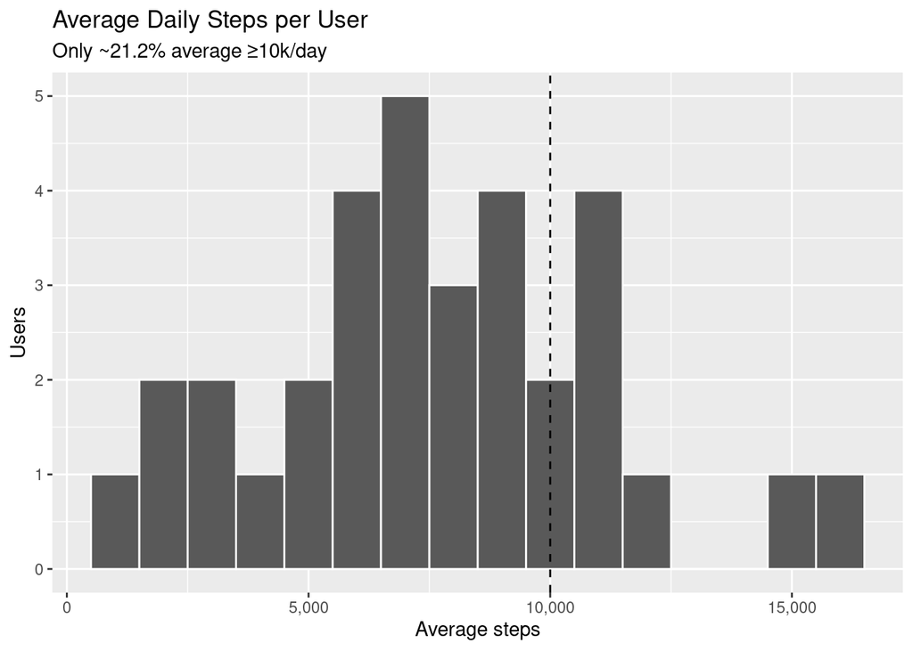

```r
ggplot(user_avg, aes(x = avg_steps)) +
  geom_histogram(binwidth = 1000, color = "white") +
  geom_vline(xintercept = 10000, linetype = "dashed") +
  scale_x_continuous(labels = label_comma()) +
  labs(title = "Average Daily Steps per User",
       subtitle = paste0("Only ~", round(pct_users_10k,1), "% average ≥10k/day"),
       x = "Average steps", y = "Users")
```

**Key finding:** Only 32.2% of all logged days reached 10,000 steps.

### Sleep Hours Distribution

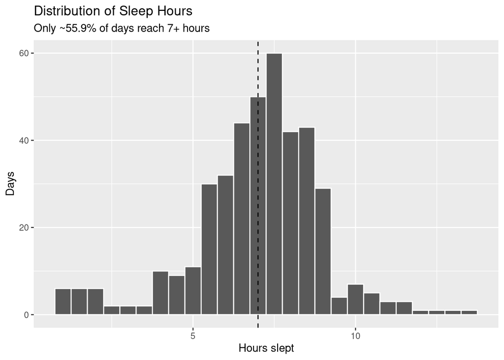

```r
ggplot(daily_sleep, aes(x = sleep_hours)) +
  geom_histogram(binwidth = 0.5, color = "white") +
  geom_vline(xintercept = 7, linetype = "dashed") +
  labs(title = "Distribution of Sleep Hours",
       subtitle = paste0("Only ~", round(pct_days_7h,1), "% of days reach 7+ hours"),
       x = "Hours slept", y = "Days")
```

**Key finding:** Only 21.2% of users average ≥10k steps/day.

### Sleep Efficiency

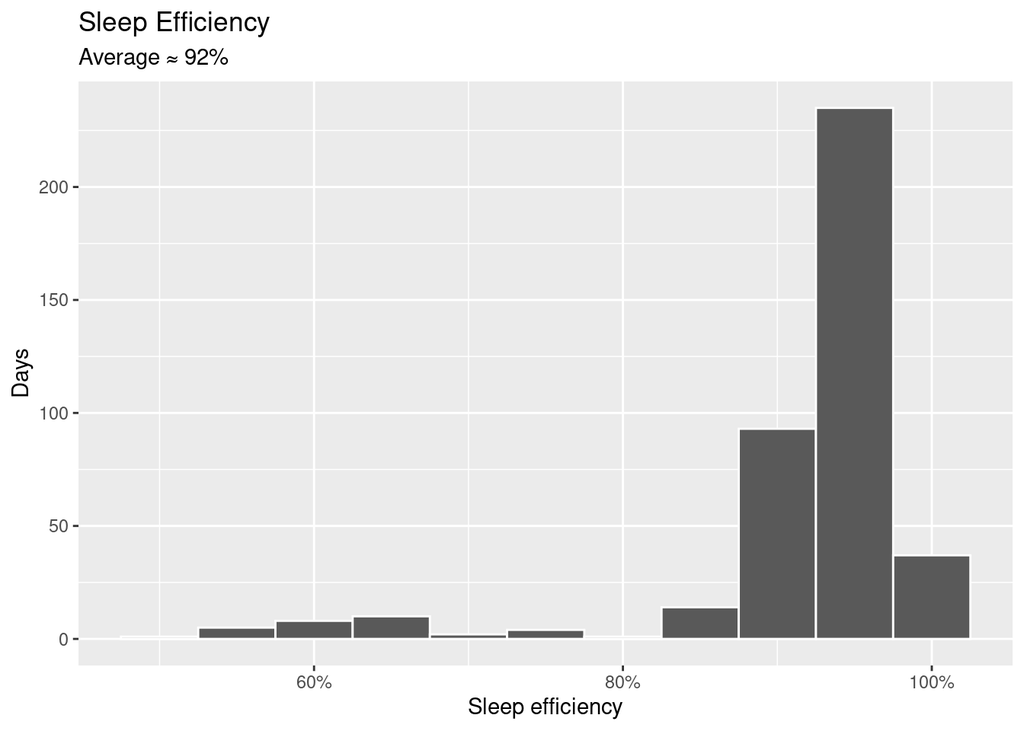

```r
ggplot(daily_sleep, aes(x = sleep_efficiency)) +
  geom_histogram(binwidth = 0.05, color = "white") +
  scale_x_continuous(labels = percent_format(accuracy = 1)) +
  labs(title = "Sleep Efficiency",
       subtitle = paste0("Average ≈ ", round(eff_mean,0), "%"),
       x = "Sleep efficiency", y = "Days")
```

**Key finding:** Avg sleep is 7h; only 55.9% of Days reach 7+ hours.

### Weight Logging Participation (if weight exists)

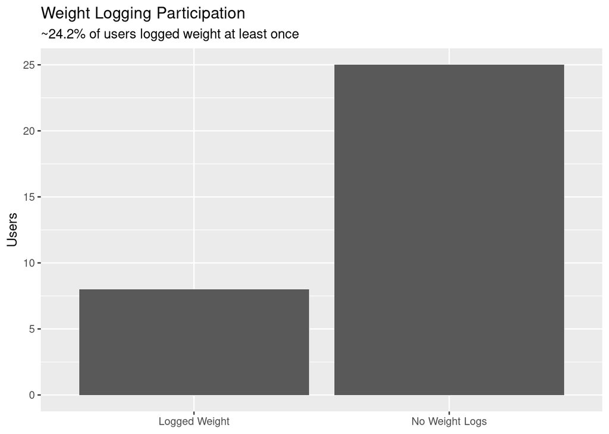

```r
if (exists("weight") && !is.na(n_users_weight)) {
  df <- tibble(
    Category = c("Logged Weight", "No Weight Logs"),
    Users = c(n_users_weight, n_users_total - n_users_weight)
  )
  ggplot(df, aes(Category, Users)) +
    geom_col() +
    labs(title = "Weight Logging Participation",
         subtitle = paste0("~", round(weight_participation_pct,1), "% of users logged weight at least once"),
         x = NULL, y = "Users")
} else {
  "No weight file available for participation chart."
}
```

**Key finding:** Users spend notable time in bed awake; avg efficiency ≈ 92%.

### Steps vs Sleep (relationship)

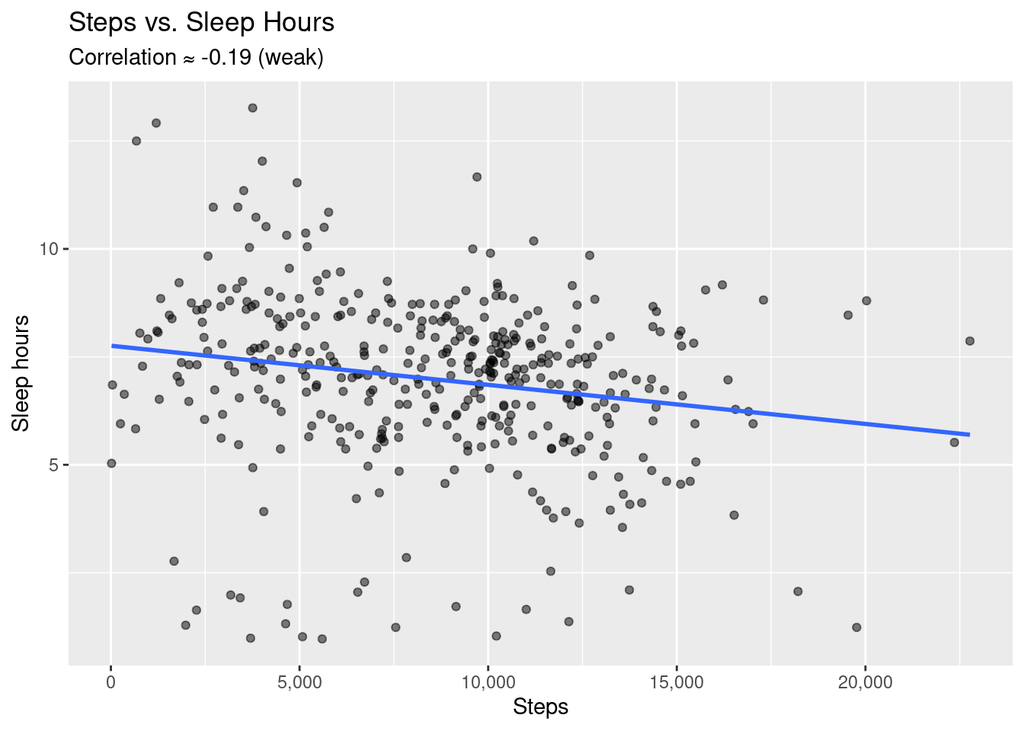

```r
ggplot(daily_sleep, aes(x = total_steps, y = sleep_hours)) +
  geom_point(alpha = 0.5) +
  geom_smooth(method = "lm", se = FALSE) +
  scale_x_continuous(labels = label_comma()) +
  labs(title = "Steps vs. Sleep Hours",
       subtitle = paste0("Correlation ≈ ", round(steps_sleep_cor,2), " (weak)"),
       x = "Steps", y = "Sleep hours")
```

**Key finding:** Only 24.2% of users Logged weight.

### Summary table

```r
knitr::kable(summary_tbl, caption = "Top Metrics Summary")
```

Top Metrics Summary

| Metric | Value |
| --- | --- |
| % of days with ≥10k steps | 32.2% |
| % of users averaging ≥10k steps/day | 21.2% |
| Average sleep hours (per day) | 7 |
| % of days with ≥7h sleep | 55.9% |
| Avg sleep efficiency (%) | 92% |
| % of users logging weight | 24.2% |
| Average BMI | 25.2 |

**Key finding:** Steps and sleep are weakly related (-0.19), so coach both **independently**.

## Act: Connecting Insights to Bellabeat Products

**Business Task Reminder:**  
Analyze smart device usage data to understand consumer habits and use these insights to make recommendations that improve Bellabeat’s marketing strategy.

**Chosen Product:**  
The **Bellabeat Leaf** – a health-focused smart jewelry piece that tracks activity, sleep, and reproductive health.

**Mapping Insights to Marketing Messages:**

1. **Steps Insight (only ~32% of days ≥10k steps):**
   - *So what?* Most users struggle to meet daily activity goals.
   - **Leaf Marketing Message:** Position the Leaf as a *personal movement coach*, offering **gentle reminders, daily challenges, and streak tracking** to keep women consistently active.
2. **Sleep Insight (low % of days with ≥7h sleep, efficiency gaps):**
   - *So what?* Many users are not getting enough quality sleep.
   - **Leaf Marketing Message:** Highlight Leaf’s **sleep tracking** and **mindfulness features** (like breathing exercises) as tools to **improve bedtime routines** and promote restorative rest.
3. **Weight Insight (low participation in logging weight):**
   - *So what?* Users avoid manual logging, showing friction.
   - **Leaf Marketing Message:** Market Leaf as a **frictionless experience** — “Unlike other devices, Leaf focuses on *automatic health tracking* so you can spend more time living, less time logging.”

**High-Level Recommendations for Bellabeat Marketing:**  
- **Target Pain Points:** Emphasize how Leaf solves the common struggles revealed in Fitbit data (inactivity, poor sleep, low weight logging engagement).  
- **Position Differentiation:** Market Leaf not just as jewelry, but as an **all-in-one wellness companion** that uniquely blends **style, automatic tracking, and holistic insights**.  
- **Engagement Features:** Promote gamified challenges (steps), bedtime coaching (sleep), and effortless tracking (weight) to connect with women seeking balance and motivation.